# reticulate - Using R for Data Wrangling and Python for A Classification Task

Manuel Tilgner (author), E Bryan Crenshaw III (implemented here)

April 04, 2020

### Objective

Introductory exercise in which R is used for data preprocessing, and Python is used in `reticulate` to train a Support Vector Machine for a simple classification task.

### Introduction

This is a worked example of the tutorial, [R and Python: Using reticulate to get the best of both worlds](https://www.statworx.com/de/blog/r-and-python-using-reticulate-to-get-the-best-of-both-worlds/). Although only a year old at the time this example was rerun, there have been numerous changes that needed to be addressed to get the example to run without error or warnings. These changes were outlined in the Conclusion section at the end of this R Markdown report. The text in the “Data Analysis” section and the first part of the “Conclusions” is from the original post. Tweeks made to the code are flagged with comment (### Updated script), and summarized at end of Conclusions.

### Approach

Follow instructions in [R and Python: Using reticulate to get the best of both worlds](https://www.statworx.com/de/blog/r-and-python-using-reticulate-to-get-the-best-of-both-worlds/). Several issues were addressed, as outlined in the Conclusions section.

```r
#Load libraries in this first chunk
library(tidyverse)
library(recipes)
library(reticulate)

# Setup python environment using conda
use_condaenv("/anaconda3/bin/python3")
py_config()
```

```
## python:         /Users/ebciii3/.virtualenvs/r-reticulate/bin/python
## libpython:      /Library/Frameworks/Python.framework/Versions/3.7/lib/python3.7/config-3.7m-darwin/libpython3.7.dylib
## pythonhome:     /Library/Frameworks/Python.framework/Versions/3.7:/Library/Frameworks/Python.framework/Versions/3.7
## version:        3.7.2 (v3.7.2:9a3ffc0492, Dec 24 2018, 02:44:43)  [Clang 6.0 (clang-600.0.57)]
## numpy:          /Users/ebciii3/.virtualenvs/r-reticulate/lib/python3.7/site-packages/numpy
## numpy_version:  1.18.2
##
## python versions found:
##  /Users/ebciii3/.virtualenvs/r-reticulate/bin/python
##  /usr/bin/python
##  /usr/local/bin/python3
##  /Users/ebciii3/anaconda/bin/python
##  /Users/ebciii3/anaconda/envs/bunnies/bin/python
##  /Users/ebciii3/anaconda/envs/r-environment/bin/python
##  /Users/ebciii3/anaconda/envs/snowflakes/bin/python
```

```r
# Load external R scripts here
# How to embed in R Markdown: < https://yihui.name/knitr/demo/externalization/ >
knitr::read_chunk('../scripts/yaml_metadata.R')
```

```r
#Load data in this chunk

#### Input File Names
input_file      <- "../data/Dispatchers_Background_Data.xls"
metadata_yml    <- '../data/Dispatchers_Background_Data.yml'

### Data Input
data <- readxl::read_xls(input_file)
```

### Input Metadata

Metadata from YAML File: ../data/Dispatchers_Background_Data.yml

| Key | Value |
| --- | --- |
| Name | Dispatchers_Background_Data.xls |
| Source | https://railroads.dot.gov/elibrary/railroad-dispatcher-background-survey |
| Website_Title | Railroad Dispatcher Background Survey |
| Download_Date | 2020-04-02 |
| Description | This data is used in a tutorial, “R and Python: Using reticulate to get the best of both worlds” at the link: https://www.statworx.com/de/blog/r-and-python-using-reticulate-to-get-the-best-of-both-wor… |

### Data Analysis

#### Data Transformation in `dplyr`

Let’s read perform some transformations with dplyr. This is mostly recoding work. As you can see in the select command, we pick a handful of variables like sex, age, caffeine consumption, health and stress to predict whether a railroad dispatcher was diagnosed with a sleeping disorder.

```r
# Data Processing
sleep <- data %>%
  select(
      Diagnosed_Sleep_disorder, Age_Group, Sex, Total_years_dispatcher,
      Total_years_present_job, Marital_Status, Childrendependents,
      Children_under_2_yrs, Caff_Beverages, Sick_Days_in_last_year,
      Health_status, Avg_Work_Hrs_Week, FRA_report, Phys_Drained,
      Mentally_Drained, Alert_at_Work, Job_Security
  ) %>%
  rename_all(tolower) %>%
  mutate_if(is.character, as.numeric) %>%
  mutate_at(vars(diagnosed_sleep_disorder, sex, caff_beverages, fra_report),
            ~ -(. - 2)) %>%
  mutate_at(vars(marital_status), ~ (. - 1)) %>%
  drop_na()
```

#### Prepare the Data

Now that we have the variables we want, it’s time to get the data into the right shape. Here’s one more reason to love `R`: the `recipes` package. If you’re not familiar with it, check it out. You may find its workflow a bit peculiar at first, but once you get used to it, it makes data preparation a breeze.

What we’re doing here is straightforward. First, we split the data into a training and test set. Next, we specify a data preparation recipe, which consists of three steps: one hot encoding factor predictors, standardising numeric predictors and down-sampling the data. One hot encoding and standardising ensure that the Support Vector Machine algorithm works properly. Down-sampling is a counter-measure against the class imbalance in our dataset.

```r
numeric_variables <- c(
  "total_years_dispatcher", "total_years_present_job",
  "childrendependents", "children_under_2_yrs",
  "sick_days_in_last_year", "avg_work_hrs_week"
)

factor_variables <- setdiff(colnames(sleep), numeric_variables)

sleep <- mutate_at(sleep, vars(factor_variables), as.factor)

set.seed(2019)
index <- sample(1:nrow(sleep), floor(nrow(sleep) * .75))

sleep_train <- sleep[index, ]
sleep_test <- sleep[-index, ]

recipe_formula <- recipes::recipe(diagnosed_sleep_disorder ~ ., sleep_train)

recipe_steps <- recipe_formula %>%
  recipes::step_dummy(factor_variables, -all_outcomes(), one_hot = TRUE) %>%
  recipes::step_downsample(diagnosed_sleep_disorder) %>%
  recipes::step_center(numeric_variables) %>%
  recipes::step_scale(numeric_variables)

recipe_prep <- recipes::prep(recipe_steps, sleep_train, retain = TRUE)

training_data <- juice(recipe_prep)
testing_data <- bake(recipe_prep, sleep_test)
```

#### Machine Learning in Python

Now comes the part where Python shines: its unified ML library scikit-learn. Let’s go ahead and import the Support Vector Machine (SVM) classifier as well as some other modules to tune and evaluate our model.

SVM is a supervised learning algorithm. It works by finding a hyperplane in an N-dimensional space, which separates two (or more) classes as cleanly as possible. More technically, SVM maximizes the margin or the distance between the separating hyperplane and the closest data points. This is why SVM is also called a maximum margin estimator.

SVM is mostly used for classification, but it can do regression too. The upside is that it works with high-dimensional data and different kernel functions, meaning it can flexibly adapt to different types of data. Its downside is that computation becomes costly with large datasets and that it reacts sensitively to hyperparameters. Still, for some applications SVM performs quite competitively.

Combining SVM with kernels allows us to project our data into a higher-dimensional space. The point of this is to make the classes better separable. In our example here, we’ll use a simple linear and a radial basis function kernel. The latter can map the predictor space into infinite dimensions.

```python
import numpy as np
import pandas as pd
import seaborn as sns
import matplotlib.pyplot as plt

from sklearn import svm
from sklearn.model_selection import GridSearchCV, cross_val_score
from sklearn.metrics import classification_report, confusion_matrix, accuracy_score

### Updated script
y_train = np.array(r.training_data['diagnosed_sleep_disorder'])
X_train = np.array(r.training_data.drop('diagnosed_sleep_disorder', axis = 1))

y_test = np.array(r.testing_data['diagnosed_sleep_disorder'])
X_test = np.array(r.testing_data.drop('diagnosed_sleep_disorder', axis = 1))
###^^^----Updated script

clf = svm.SVC(kernel = 'linear', gamma='scale')
clf.fit(X_train, y_train)
```

```
## SVC(C=1.0, break_ties=False, cache_size=200, class_weight=None, coef0=0.0,
##     decision_function_shape='ovr', degree=3, gamma='scale', kernel='linear',
##     max_iter=-1, probability=False, random_state=None, shrinking=True,
##     tol=0.001, verbose=False)
```

```python
y_pred = clf.predict(X_test)

print(confusion_matrix(y_test, y_pred))
```

```
## [[69 24]
##  [ 6  5]]
```

```python
print(classification_report(y_test, y_pred))

### Updated script
```

```
##               precision    recall  f1-score   support
##
##            0       0.92      0.74      0.82        93
##            1       0.17      0.45      0.25        11
##
##     accuracy                           0.71       104
##    macro avg       0.55      0.60      0.54       104
## weighted avg       0.84      0.71      0.76       104
```

```python
clf = svm.SVC(kernel = 'rbf', gamma='scale') # was originally 'RBF'
clf.fit(X_train, y_train)
```

```
## SVC(C=1.0, break_ties=False, cache_size=200, class_weight=None, coef0=0.0,
##     decision_function_shape='ovr', degree=3, gamma='scale', kernel='rbf',
##     max_iter=-1, probability=False, random_state=None, shrinking=True,
##     tol=0.001, verbose=False)
```

```python
y_pred = clf.predict(X_test)

print(confusion_matrix(y_test, y_pred))
```

```
## [[56 37]
##  [ 7  4]]
```

```python
print(classification_report(y_test, y_pred))
```

```
##               precision    recall  f1-score   support
##
##            0       0.89      0.60      0.72        93
##            1       0.10      0.36      0.15        11
##
##     accuracy                           0.58       104
##    macro avg       0.49      0.48      0.44       104
## weighted avg       0.81      0.58      0.66       104
```

#### Tune the Model

```python
### Updated script
param_grid = [{'C': [0.01, 0.1, 1, 10, 100],
               'gamma': [0.001, 0.01, 0.1, 1, 10],
               'kernel': ['rbf', 'linear']}] # RBF

### Updated script
grid = GridSearchCV(svm.SVC(), param_grid, cv = 5, scoring = 'balanced_accuracy', iid=True)

grid.fit(X_train, y_train)
```

```
## GridSearchCV(cv=5, error_score=nan,
##              estimator=SVC(C=1.0, break_ties=False, cache_size=200,
##                            class_weight=None, coef0=0.0,
##                            decision_function_shape='ovr', degree=3,
##                            gamma='scale', kernel='rbf', max_iter=-1,
##                            probability=False, random_state=None, shrinking=True,
##                            tol=0.001, verbose=False),
##              iid=True, n_jobs=None,
##              param_grid=[{'C': [0.01, 0.1, 1, 10, 100],
##                           'gamma': [0.001, 0.01, 0.1, 1, 10],
##                           'kernel': ['rbf', 'linear']}],
##              pre_dispatch='2*n_jobs', refit=True, return_train_score=False,
##              scoring='balanced_accuracy', verbose=0)
##
```

```python
print(grid.best_params_)
```

```
## {'C': 100, 'gamma': 0.001, 'kernel': 'rbf'}
```

#### Evaluate the Accuracy of the Model

```python
lf = grid.best_estimator_
y_pred = clf.predict(X_test)

print('Confusion Matrix:\n\n', confusion_matrix(y_test, y_pred))
```

```
## Confusion Matrix:
##
##  [[56 37]
##  [ 7  4]]
```

```python
print('\nClassification Report:\n\n', classification_report(y_test, y_pred))
```

```
##
## Classification Report:
##
##                precision    recall  f1-score   support
##
##            0       0.89      0.60      0.72        93
##            1       0.10      0.36      0.15        11
##
##     accuracy                           0.58       104
##    macro avg       0.49      0.48      0.44       104
## weighted avg       0.81      0.58      0.66       104
```

```python
print('\nTraining Set Accuracy: {:.2f}%'.format(clf.score(X_train, y_train)))
```

```
##
## Training Set Accuracy: 0.88%
```

```python
print('\nTest Set Accuracy: {:.2f}%'.format(clf.score(X_test, y_test)))
```

```
##
## Test Set Accuracy: 0.58%
```

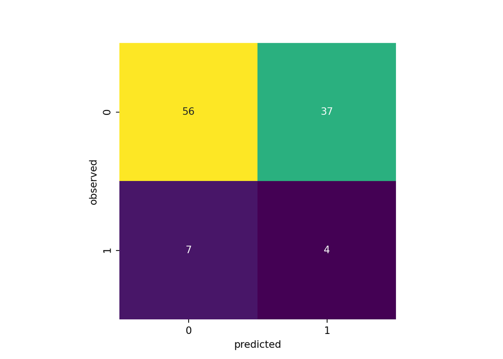

```python
# This chunk has been left unevaluated, because RMarkdown can't find the .png output
conf_mat = confusion_matrix(y_test, y_pred)

sns.heatmap(conf_mat, square = True, annot = True, fmt = 'g',
            cbar = False, cmap = 'viridis')
plt.xlabel('predicted')
plt.ylabel('observed')
plt.show()
```

### Conclusion

#### Updates Needed

Several tweeks were made to this tutorial to get it to run without errors or warnings:  
- The test and training data needed to be explicitly converted to np.array (e.g., y_train = np.array(…)) to avoid an error.  
- ‘RBF’ had to be changed to ‘rbf’ to avoid an error, and `gamma` needed to made explicit to address warnings (e.g, `svm.SVC(kernel = 'rbf', gamma='scale')`).  
- To the `grid` assignment in “Tune the model,” `, iid=True` had to be added to address warnings about changes in the versions.

```r
py_config()
```

```
## python:         /Users/ebciii3/.virtualenvs/r-reticulate/bin/python
## libpython:      /Library/Frameworks/Python.framework/Versions/3.7/lib/python3.7/config-3.7m-darwin/libpython3.7.dylib
## pythonhome:     /Library/Frameworks/Python.framework/Versions/3.7:/Library/Frameworks/Python.framework/Versions/3.7
## version:        3.7.2 (v3.7.2:9a3ffc0492, Dec 24 2018, 02:44:43)  [Clang 6.0 (clang-600.0.57)]
## numpy:          /Users/ebciii3/.virtualenvs/r-reticulate/lib/python3.7/site-packages/numpy
## numpy_version:  1.18.2
##
## python versions found:
##  /Users/ebciii3/.virtualenvs/r-reticulate/bin/python
##  /usr/bin/python
##  /usr/local/bin/python3
##  /Users/ebciii3/anaconda/bin/python
##  /Users/ebciii3/anaconda/envs/bunnies/bin/python
##  /Users/ebciii3/anaconda/envs/r-environment/bin/python
##  /Users/ebciii3/anaconda/envs/snowflakes/bin/python
```

```r
print(paste0("This R Markdown Document was run on ",format(Sys.Date(),"%d-%b-%Y")))
```

```
## [1] "This R Markdown Document was run on 04-Apr-2020"
```

```r
# If the user in not inside RStudio, then this will send a notification to the OS
# NOTE: Notifier was not on CRAN in March 2019
# To get package:
#install.packages("devtools") if devtools is not installed
#devtools::install_github("gaborcsardi/notifier")
################################################
require(notifier)
msg <- paste0(doc_title, " is done!")
notifier::notify(msg, title = "R notification", image = NULL)
```